# Ford GoBike Data Analysis 2019

## by Adnan Aldajani

## Investigation Overview

My main goal of this presentation is to compare the genders in the dataset and see what gender uses the service and what gender have more trip duration. Also, to have a look on the performance of the service in various days of the week.

## Dataset Overview

The data is a data of Ford bike rental service in San Francisco Bay Area in 2019. It shows timing of start to end of the rental trip, start and end startion and which bike is used.

## Differenece Between Number of Users of Different Genders

Before the start of the analysis, we want to check relation between number of users to the gender of the user. We can see that the proportion of males is very high compared to females and other genders.

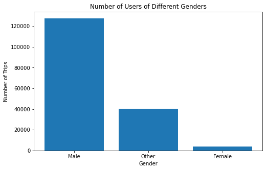

## Duration of Trips in the Days of the Week

Now, We want to check how each day of the week do in terms of durations. We can see that Sundays and Saturday tend to have more duration than others.

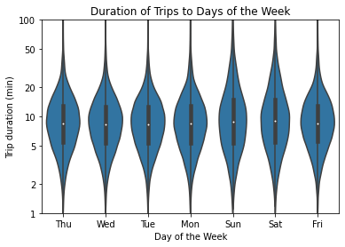

## Trip Duration, Gender and Age Relation

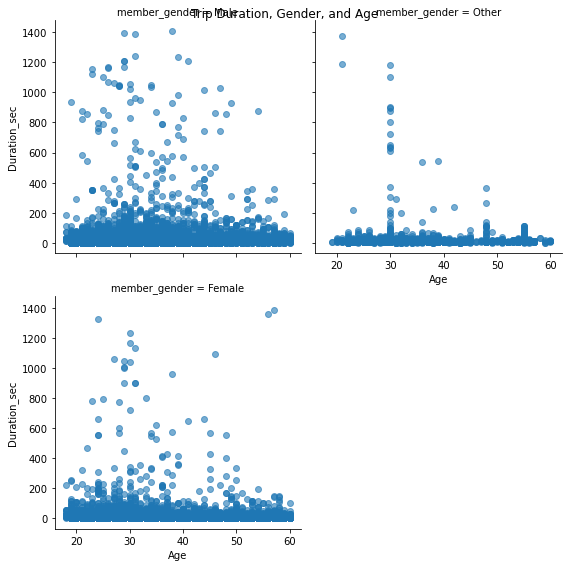